# Análisis y Arquetipos de Pokémon

[figure not shown]

[figure not shown]

[figure not shown]

[figure not shown]

[figure not shown]

# Resumen Ejecutivo

### Total Especies

386

### Tipos Principales

17

### Legendarios

17

### Estadísticas

410

### Distribución de Pokémon por Tipo Principal

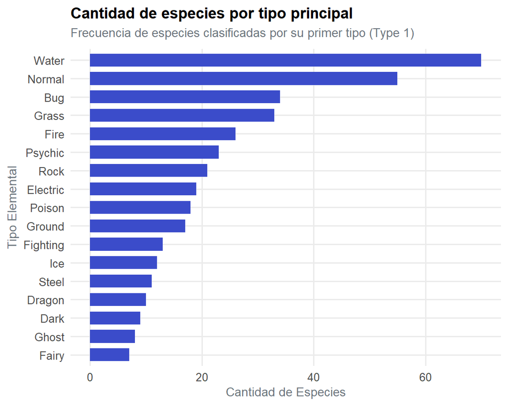

### Relación: Ataque vs Defensa

[interactive chart not shown]

# Tipos y Generaciones

### Cómo leer esta página

> **Tipos (pregunta 1):** el heatmap muestra el promedio de cada estadística por tipo principal. Un color más intenso indica un promedio más alto. El número entre paréntesis es cuántos Pokémon hay de ese tipo: los tipos con pocos Pokémon deben interpretarse con cuidado. **Generaciones (pregunta 3):** la gráfica de caja compara las estadísticas totales de cada generación; cada punto es un Pokémon y puedes pasar el cursor para ver cuál es.

### Perfil Estadístico por Tipo Principal

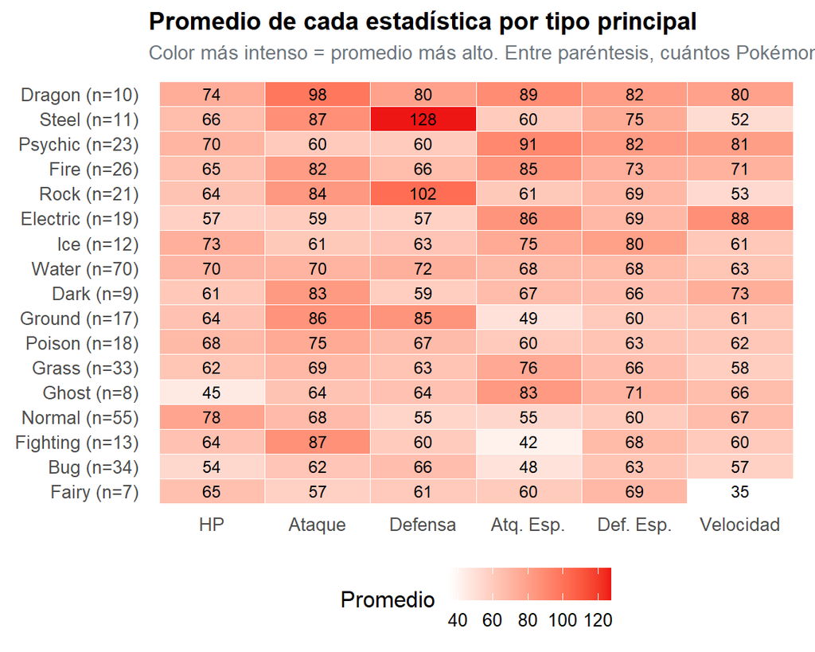

### Estadísticas Totales por Generación

[interactive chart not shown]

### Resumen por Generación

| Generación | Pokémon | Mediana Total | Promedio Total | Legendarios + Míticos |
| --- | --- | --- | --- | --- |
| I | 151 | 405 | 407.6 | 5 |
| II | 100 | 415 | 407.2 | 6 |
| III | 135 | 410 | 403.7 | 10 |

# Modelado: Arquetipos

### Lectura Analítica del Modelo

> **¿Por qué Clustering?** Agrupar Pokémon por su “Tipo” (Fuego, Agua, etc.) ignora sus verdaderas capacidades de combate. Utilizamos un algoritmo **K-Means** sobre las 6 estadísticas base escaladas (HP, Ataque, Defensa, Ataque Especial, Defensa Especial y Velocidad) para descubrir 4 roles orgánicos (arquetipos) en los datos. La tabla Tipo × Arquetipo al final de esta página permite comprobar si los Pokémon de un mismo tipo se reparten en varios arquetipos o se concentran en uno solo

### Los 4 Arquetipos de Combate (Perfil Estadístico)

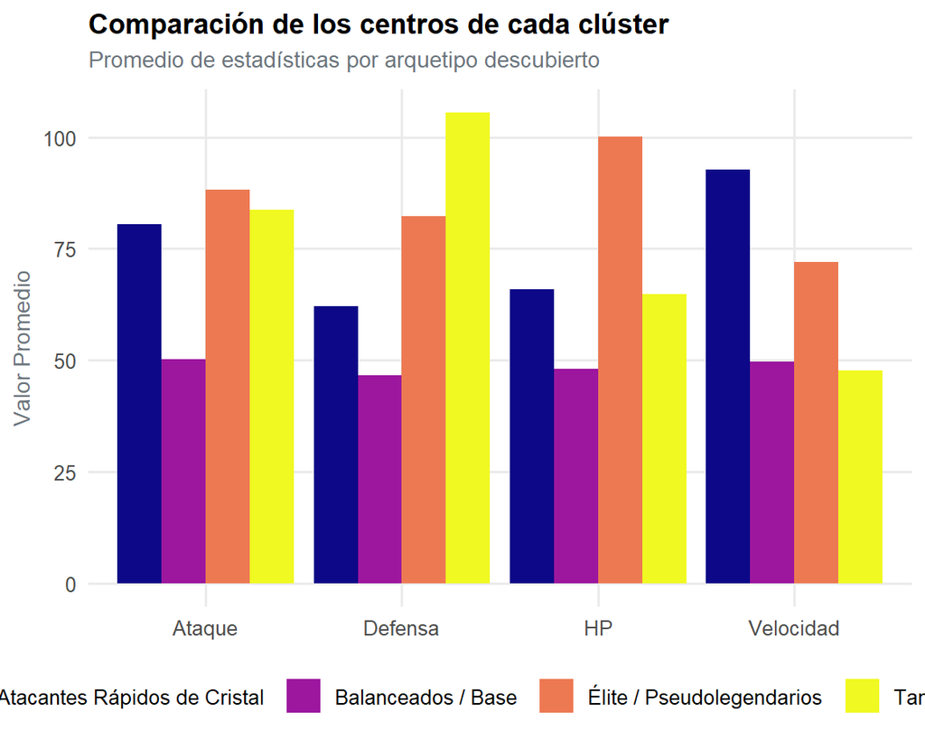

### Exploración Interactiva por Arquetipo

[interactive chart not shown]

### ¿Un mismo tipo aparece en varios arquetipos? (Tipo × Arquetipo)

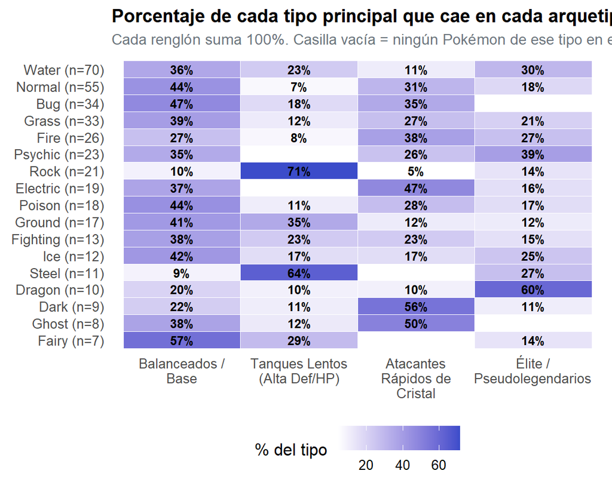

# Equipo Equilibrado

### Regla para armar el equipo

> **Regla por rondas (pregunta 5).** **Ronda 1:** se elige al Pokémon de mayor total de stats de cada uno de los 4 arquetipos. **Ronda 2:** los 2 lugares restantes se llenan con los de mayor total que queden. **En ambas rondas** no se permite repetir tipo principal: si el mejor candidato tiene un tipo que ya está en el equipo, se pasa al siguiente. Por defecto se excluyen legendarios y míticos (se puede cambiar con `incluir_legendarios` en el código).

### Poder del Equipo

3,320

### Tipos Distintos

6

### Arquetipos Cubiertos

4 de 4

### Integrantes del Equipo

| Nombre | Tipo Principal | Tipo Secundario | Arquetipo | Total Stats | ¿Por qué entró? |
| --- | --- | --- | --- | --- | --- |
| Slaking | Normal |  | Élite / Pseudolegendarios | 670 | Ronda 1: mejor de su arquetipo |
| Crobat | Poison | Flying | Atacantes Rápidos de Cristal | 535 | Ronda 1: mejor de su arquetipo |
| Aggron | Steel | Rock | Tanques Lentos (Alta Def/HP) | 530 | Ronda 1: mejor de su arquetipo |
| Dustox | Bug | Poison | Balanceados / Base | 385 | Ronda 1: mejor de su arquetipo |
| Dragonite | Dragon | Flying | Élite / Pseudolegendarios | 600 | Ronda 2: relleno por total |
| Tyranitar | Rock | Dark | Élite / Pseudolegendarios | 600 | Ronda 2: relleno por total |

### Promedio del Equipo vs Todos los Candidatos

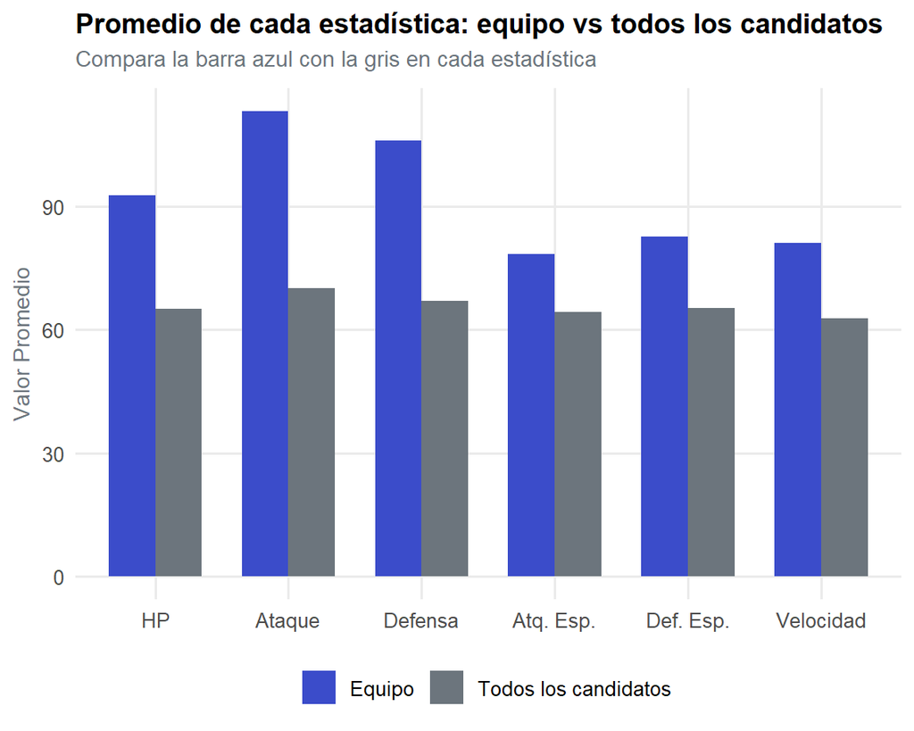

# Explorador de Datos

### Uso de esta página

> **Herramienta de validación.** Esta vista permite a los usuarios buscar y filtrar Pokémon específicos para validar a qué arquetipo (clúster) fueron asignados por el modelo de Machine Learning.

### Base de Datos Completa

| ID | Nombre | Tipo Principal | Total Stats | Ataque | Defensa | Velocidad | Arquetipo |
| --- | --- | --- | --- | --- | --- | --- | --- |
| 1 | Bulbasaur | Grass | 318 | 49 | 49 | 45 | Balanceados / Base |
| 2 | Ivysaur | Grass | 405 | 62 | 63 | 60 | Atacantes Rápidos de Cristal |
| 3 | Venusaur | Grass | 525 | 82 | 83 | 80 | Élite / Pseudolegendarios |
| 4 | Charmander | Fire | 309 | 52 | 43 | 65 | Balanceados / Base |
| 5 | Charmeleon | Fire | 405 | 64 | 58 | 80 | Atacantes Rápidos de Cristal |
| 6 | Charizard | Fire | 534 | 84 | 78 | 100 | Atacantes Rápidos de Cristal |
| 7 | Squirtle | Water | 314 | 48 | 65 | 43 | Balanceados / Base |
| 8 | Wartortle | Water | 405 | 63 | 80 | 58 | Tanques Lentos (Alta Def/HP) |
| 9 | Blastoise | Water | 530 | 83 | 100 | 78 | Élite / Pseudolegendarios |
| 10 | Caterpie | Bug | 195 | 30 | 35 | 45 | Balanceados / Base |

[output cut: 376 more lines]

````r
---
title: "Análisis y Arquetipos de Pokémon"
subtitle: "¿Podemos agruparlos más allá de sus tipos elementales?"
date: "`r format(Sys.Date(), '%d %B %Y')`"
output:
  flexdashboard::flex_dashboard:
    orientation: rows
    vertical_layout: scroll
    theme: cosmo
    source_code: embed
    self_contained: true
---

```{r setup, include=FALSE}
library(flexdashboard)
library(tidyverse)
library(scales)
library(DT)
library(plotly)
library(httr)      # Necesario para la función GET()
library(jsonlite)  # Necesario para la función fromJSON()

knitr::opts_chunk$set(
  echo = FALSE,
  message = FALSE,
  warning = FALSE
)

# -----------------------------------------------------------------------------
# OBTENCIÓN Y LIMPIEZA DE DATOS
# -----------------------------------------------------------------------------
get_pokemon_data <- function(id) {
  # 1. Armamos las DOS direcciones: la ficha de combate y la ficha de especie
  #    (la barra diagonal final evita redirecciones 301)
  url_pokemon <- paste0("https://pokeapi.co/api/v2/pokemon/", id, "/")         # stats y tipos
  url_especie <- paste0("https://pokeapi.co/api/v2/pokemon-species/", id, "/")  # generación, legendario, mítico

  # 2. Usamos tryCatch para que si falla una descarga, no se detenga todo el programa
  tryCatch({
    contenido <- fromJSON(url_pokemon)  # ficha de combate
    especie   <- fromJSON(url_especie)  # ficha de especie (nuevo)

    stats <- contenido$stats$base_stat # vector numérico de stats
    names(stats) <- contenido$stats$stat$name # nombres para el vector numérico de stats

    # --- Tipos (nuevo) ---
    tipos <- contenido$types$type$name         # vector con 1 o 2 tipos, p. ej. c("grass", "poison")
    tipo_principal  <- str_to_title(tipos[1])  # el primer tipo siempre existe
    tipo_secundario <- str_to_title(tipos[2])  # si solo hay un tipo, tipos[2] devuelve NA

    # --- Generación (nuevo) ---
    generacion <- especie$generation$name               # la API la da como "generation-ii"
    generacion <- str_remove(generacion, "generation-") # quitamos el prefijo: "ii"
    generacion <- str_to_upper(generacion)              # a mayúsculas: "II"

    df <- tibble(
      id = contenido$id,
      name = str_to_title(contenido$name),
      type_1 = tipo_principal,
      type_2 = tipo_secundario,          # nuevo: tipo secundario (NA si no tiene)
      generation = generacion,           # nuevo: "I", "II" o "III"
      hp = stats["hp"],
      attack = stats["attack"],
      defense = stats["defense"],
      sp_atk = stats["special-attack"],
      sp_def = stats["special-defense"],
      speed = stats["speed"],
      total = sum(stats),
      legendary = especie$is_legendary,  # nuevo: TRUE/FALSE directo de la API
      mythical = especie$is_mythical     # nuevo: TRUE/FALSE directo de la API
    )

    # 3. Pequeña pausa de 0.1 segundos para respetar los límites de la API
    Sys.sleep(0.1)

    return(df)

  }, error = function(e) {
    # Si hay error de red, imprime un mensaje pero continúa con el siguiente Pokémon
    message(paste("Error descargando ID:", id))
    return(NULL)
  })
}


# -----------------------------------------------------------------------------
# CACHÉ LOCAL: descargar una sola vez y reutilizar el CSV
# -----------------------------------------------------------------------------
archivo_csv <- "pokemon_gen1_3.csv"   # nombre del archivo que funcionará como "cajón"
total_esperado <- 386                 # Pokémon de las generaciones I, II y III

if (file.exists(archivo_csv)) {

  # El CSV ya existe: lo leemos y NO llamamos a la API
  pokemon_raw <- read_csv(archivo_csv, show_col_types = FALSE)  # show_col_types evita el mensaje de columnas

} else {

  # El CSV no existe: descargamos desde la API (2 peticiones por Pokémon, tarda varios minutos)
  pokemon_raw <- map_df(1:total_esperado, get_pokemon_data)

  # Solo guardamos si llegaron todos; así nunca queda guardada una descarga incompleta
  if (nrow(pokemon_raw) == total_esperado) {
    write_csv(pokemon_raw, archivo_csv)   # se guarda en la misma carpeta que el .Rmd
  } else {
    message(paste(
      "Descarga incompleta:", nrow(pokemon_raw), "de", total_esperado,
      "Pokémon. No se guardó el CSV; vuelve a hacer knit para reintentar."
    ))
  }

}




# Limpieza
pokemon <- pokemon_raw |>
  filter(!str_detect(name, "Mega ")) |>
  drop_na(name) |>   # OJO: solo revisa la columna name, así no borra los NA de type_2
  mutate(
    # Convertimos la generación en factor para que siempre se ordene I, II, III
    generation = factor(generation, levels = c("I", "II", "III"))
  )

# -----------------------------------------------------------------------------
# CÁLCULO DE KPIs
# -----------------------------------------------------------------------------
kpi_total <- nrow(pokemon)
kpi_tipos <- n_distinct(pokemon$type_1)
kpi_legendarios <- sum(pokemon$legendary)
kpi_mediana_total <- median(pokemon$total)

# -----------------------------------------------------------------------------
# MODELADO: CLUSTERING (K-MEANS)
# -----------------------------------------------------------------------------
stats_cols <- c("hp", "attack", "defense", "sp_atk", "sp_def", "speed")

# Extraer y escalar estadísticas para el modelo (media 0, sd 1)
pokemon_stats <- pokemon |>
  select(all_of(stats_cols)) |>
  scale()

# Entrenar K-Means con 4 centros (arquetipos)
set.seed(123)
modelo_kmeans <- kmeans(pokemon_stats, centers = 4, nstart = 25)



# Integrar el número de clúster al dataframe (todavía sin nombre)
pokemon <- pokemon |>
  mutate(cluster = as.factor(modelo_kmeans$cluster))

# -----------------------------------------------------------------------------
# NOMBRAR ARQUETIPOS SEGÚN SU PERFIL
# -----------------------------------------------------------------------------
# Promedio de stats de cada clúster: esto nos dice "cómo juega" cada equipo
perfil_clusters <- pokemon |>
  group_by(cluster) |>
  summarise(
    total_prom = mean(total),      # fuerza general del clúster
    speed_prom = mean(speed),      # velocidad promedio del clúster
    .groups = "drop"
  )
````

````r
# Paso 1: Élite = el clúster con MAYOR total promedio
cl_elite <- perfil_clusters$cluster[which.max(perfil_clusters$total_prom)]  # which.max da la posición del máximo
restantes <- perfil_clusters |> filter(cluster != cl_elite)                 # lo quitamos de la lista

# Paso 2: Base = el clúster con MENOR total promedio entre los que quedan
cl_base <- restantes$cluster[which.min(restantes$total_prom)]  # which.min da la posición del mínimo
restantes <- restantes |> filter(cluster != cl_base)           # lo quitamos de la lista

# Paso 3: Rápidos = el MÁS VELOZ de los dos que quedan
cl_rapidos <- restantes$cluster[which.max(restantes$speed_prom)]
restantes <- restantes |> filter(cluster != cl_rapidos)

# Paso 4: Tanques = el único clúster que queda
cl_tanques <- restantes$cluster

# Asignar el nombre a cada Pokémon según el clúster que le tocó
pokemon <- pokemon |>
  mutate(
    arquetipo = case_when(
      cluster == cl_elite   ~ "Élite / Pseudolegendarios",
      cluster == cl_base    ~ "Balanceados / Base",
      cluster == cl_rapidos ~ "Atacantes Rápidos de Cristal",
      cluster == cl_tanques ~ "Tanques Lentos (Alta Def/HP)"
    )
  )





# Resumen para gráficas
tipos_resumen <- pokemon |>
  group_by(type_1) |>
  summarise(cantidad = n(), .groups = "drop") |>
  arrange(desc(cantidad))

# -----------------------------------------------------------------------------
# DISEÑO VISUAL
# -----------------------------------------------------------------------------
rojo_pk <- "#EE1515"
azul_pk <- "#3B4CCA"
amarillo_pk <- "#FFDE00"
gris <- "#6C757D"

tema_dashboard <- theme_minimal(base_size = 12) +
  theme(
    plot.title = element_text(face = "bold", size = 13, margin = margin(b = 5)),
    plot.subtitle = element_text(size = 10.5, color = gris, margin = margin(b = 8)),
    axis.title = element_text(size = 10.5, color = gris),
    panel.grid.minor = element_blank(),
    legend.position = "bottom"
  )




# -----------------------------------------------------------------------------
# EQUIPO EQUILIBRADO: REGLA SENCILLA POR RONDAS
# -----------------------------------------------------------------------------
# Interruptor: cambia a TRUE si quieres permitir legendarios y míticos
incluir_legendarios <- FALSE

# Candidatos: todos los Pokémon, quitando legendarios y míticos si el interruptor está en FALSE
candidatos <- pokemon
if (!incluir_legendarios) {
  candidatos <- candidatos |> filter(!legendary, !mythical)  # ! significa "NO"
}

# El equipo empieza vacío
equipo <- tibble()

# --- Ronda 1: el mejor de cada arquetipo, sin repetir tipo principal ---
orden_arquetipos <- c(
  "Élite / Pseudolegendarios",
  "Atacantes Rápidos de Cristal",
  "Tanques Lentos (Alta Def/HP)",
  "Balanceados / Base"
)

for (arq in orden_arquetipos) {                          # un turno por cada arquetipo
  elegido <- candidatos |>
    filter(arquetipo == arq) |>                          # solo Pokémon de este arquetipo
    filter(!type_1 %in% equipo$type_1) |>                # que su tipo NO esté ya en el equipo
    slice_max(total, n = 1, with_ties = FALSE) |>        # el de mayor total (exactamente 1)
    mutate(ronda = "Ronda 1: mejor de su arquetipo")     # anotamos por qué entró
  equipo <- bind_rows(equipo, elegido)                   # lo agregamos al equipo
}

# --- Ronda 2: rellenar hasta 6 con los mejores restantes, sin repetir tipo principal ---
lugares_restantes <- 6 - nrow(equipo)                    # después de la Ronda 1 normalmente quedan 2

for (i in 1:lugares_restantes) {                         # un turno por cada lugar libre
  elegido <- candidatos |>
    filter(!id %in% equipo$id) |>                        # que no esté ya en el equipo
    filter(!type_1 %in% equipo$type_1) |>                # que su tipo NO esté ya en el equipo
    slice_max(total, n = 1, with_ties = FALSE) |>        # el de mayor total
    mutate(ronda = "Ronda 2: relleno por total")
  equipo <- bind_rows(equipo, elegido)
}


```










































Resumen Ejecutivo
===============================

Row
-------------------------------

### Total Especies

```{r}
valueBox(
  value = comma(kpi_total),
  caption = "Especies Analizadas",
  icon = "fa-paw",
  color = "primary"
)
```

### Tipos Principales

```{r}
valueBox(
  value = kpi_tipos,
  caption = "Tipos elementales distintos",
  icon = "fa-leaf",
  color = "info"
)
```

### Legendarios

```{r}
valueBox(
  value = kpi_legendarios,
  caption = "Pokémon Legendarios",
  icon = "fa-star",
  color = "warning"
)
```

### Estadísticas

```{r}
valueBox(
  value = kpi_mediana_total,
  caption = "Mediana de Puntos Totales",
  icon = "fa-bar-chart",
  color = "primary"
)
```

Row
-------------------------------

### Distribución de Pokémon por Tipo Principal {data-width=650}

```{r}
ggplot(tipos_resumen, aes(x = reorder(type_1, cantidad), y = cantidad)) +
  geom_col(fill = azul_pk, width = 0.7) +
  coord_flip() +
  labs(
    title = "Cantidad de especies por tipo principal",
    subtitle = "Frecuencia de especies clasificadas por su primer tipo (Type 1)",
    x = "Tipo Elemental",
    y = "Cantidad de Especies"
  ) +
  tema_dashboard
```

### Relación: Ataque vs Defensa {data-width=350}

```{r}
g_dispersion <- ggplot(pokemon, aes(x = attack, y = defense, color = legendary, text = name)) +
  geom_point(alpha = 0.7, size = 2) +
  scale_color_manual(values = c("FALSE" = gris, "TRUE" = amarillo_pk)) +
  labs(
    title = "Ataque vs Defensa, con legendarios resaltados",
    subtitle = "Ataque físico vs Defensa física",
    x = "Ataque",
    y = "Defensa",
    color = "¿Legendario?"
  ) +
  tema_dashboard +
  theme(legend.position = "none")

ggplotly(g_dispersion, tooltip = "text")
```







































Tipos y Generaciones
===============================

Row
-------------------------------

### Cómo leer esta página

> **Tipos (pregunta 1):** el heatmap muestra el promedio de cada estadística por tipo principal. Un color más intenso indica un promedio más alto. El número entre paréntesis es cuántos Pokémon hay de ese tipo: los tipos con pocos Pokémon deben interpretarse con cuidado. **Generaciones (pregunta 3):** la gráfica de caja compara las estadísticas totales de cada generación; cada punto es un Pokémon y puedes pasar el cursor para ver cuál es.
````

````r
Row {data-height=700}
-------------------------------

### Perfil Estadístico por Tipo Principal

```{r}
# -----------------------------------------------------------------------------
# HEATMAP: PROMEDIO DE CADA STAT POR TIPO PRINCIPAL
# -----------------------------------------------------------------------------
# Paso 1: una fila por tipo, con el promedio de cada stat y cuántos Pokémon tiene
promedio_tipo <- pokemon |>
  group_by(type_1) |>
  summarise(
    n = n(),                       # cantidad de Pokémon de este tipo
    hp = mean(hp),                 # promedio de cada stat
    attack = mean(attack),
    defense = mean(defense),
    sp_atk = mean(sp_atk),
    sp_def = mean(sp_def),
    speed = mean(speed),
    total_prom = mean(total),      # lo usaremos solo para ordenar los renglones
    .groups = "drop"
  ) |>
  mutate(tipo_etiqueta = paste0(type_1, " (n=", n, ")"))  # ej. "Fire (n=22)"

# Paso 2: pasar a formato largo (una fila por combinación tipo-stat), que es lo que pide geom_tile
heatmap_tipo <- promedio_tipo |>
  pivot_longer(
    cols = all_of(stats_cols),     # las 6 stats que definimos en setup
    names_to = "estadistica",
    values_to = "promedio"
  ) |>
  mutate(
    # Nombres en español y en el orden de stats_cols para el eje X
    estadistica = factor(
      estadistica,
      levels = stats_cols,
      labels = c("HP", "Ataque", "Defensa", "Atq. Esp.", "Def. Esp.", "Velocidad")
    )
  )

# Paso 3: dibujar el heatmap
ggplot(
  heatmap_tipo,
  aes(
    x = estadistica,
    y = reorder(tipo_etiqueta, total_prom),  # tipos ordenados por su total promedio
    fill = promedio
  )
) +
  geom_tile(color = "white") +                          # cada casilla, con borde blanco
  geom_text(aes(label = round(promedio)), size = 3.2) + # el número dentro de la casilla
  scale_fill_gradient(low = "white", high = rojo_pk) +  # de blanco (bajo) a rojo (alto)
  labs(
    title = "Promedio de cada estadística por tipo principal",
    subtitle = "Color más intenso = promedio más alto. Entre paréntesis, cuántos Pokémon hay de ese tipo",
    x = NULL,
    y = NULL,
    fill = "Promedio"
  ) +
  tema_dashboard +
  theme(panel.grid = element_blank())                   # sin cuadrícula detrás de las casillas
```

Row
-------------------------------

### Estadísticas Totales por Generación {data-width=600}

```{r}
# -----------------------------------------------------------------------------
# COMPARACIÓN DE STATS TOTALES POR GENERACIÓN
# -----------------------------------------------------------------------------
g_generacion <- ggplot(pokemon, aes(x = generation, y = total)) +
  # La caja: mitad central de los Pokémon y la mediana (línea)
  # outlier.shape = NA evita dibujar dos veces los puntos extremos (ya salen en el jitter)
  geom_boxplot(aes(fill = generation), alpha = 0.4, outlier.shape = NA, width = 0.5) +
  # Cada Pokémon como un punto, un poco dispersado a los lados para que no se encimen
  geom_jitter(
    aes(text = paste("Nombre:", name, "<br>Tipo:", type_1, "<br>Total:", total)),
    width = 0.15, alpha = 0.5, size = 1.5, color = gris
  ) +
  scale_fill_manual(values = c("I" = rojo_pk, "II" = azul_pk, "III" = amarillo_pk)) +
  labs(
    title = "Distribución de estadísticas totales por generación",
    subtitle = "La caja muestra el 50% central y la línea la mediana; cada punto es un Pokémon",
    x = "Generación",
    y = "Total de Stats"
  ) +
  tema_dashboard +
  theme(legend.position = "none")

ggplotly(g_generacion, tooltip = "text")
```

### Resumen por Generación {data-width=400}

```{r}
# Tabla pequeña con los números detrás de la gráfica
resumen_generacion <- pokemon |>
  group_by(generation) |>
  summarise(
    Pokémon = n(),
    `Mediana Total` = median(total),
    `Promedio Total` = round(mean(total), 1),
    `Legendarios + Míticos` = sum(legendary | mythical),  # | significa "o": cuenta si es cualquiera de los dos
    .groups = "drop"
  ) |>
  rename(Generación = generation)

DT::datatable(
  resumen_generacion,
  rownames = FALSE,
  options = list(dom = "t")   # "t" = solo la tabla, sin buscador ni paginación
)
```












































Modelado: Arquetipos
===============================

Row
-------------------------------

### Lectura Analítica del Modelo

> **¿Por qué Clustering?** Agrupar Pokémon por su "Tipo" (Fuego, Agua, etc.) ignora sus verdaderas capacidades de combate. Utilizamos un algoritmo **K-Means** sobre las 6 estadísticas base escaladas (HP, Ataque, Defensa, Ataque Especial, Defensa Especial y Velocidad) para descubrir 4 roles orgánicos (arquetipos) en los datos. La tabla Tipo × Arquetipo al final de esta página permite comprobar si los Pokémon de un mismo tipo se reparten en varios arquetipos o se concentran en uno solo

Row
-------------------------------

### Los 4 Arquetipos de Combate (Perfil Estadístico) {data-width=500}

```{r}
resumen_cluster <- pokemon |>
  group_by(arquetipo) |>
  summarise(
    Ataque = mean(attack),
    Defensa = mean(defense),
    Velocidad = mean(speed),
    HP = mean(hp),
    .groups = "drop"
  ) |>
  pivot_longer(cols = -arquetipo, names_to = "estadistica", values_to = "valor")

ggplot(resumen_cluster, aes(x = estadistica, y = valor, fill = arquetipo)) +
  geom_col(position = "dodge") +
  scale_fill_viridis_d(option = "plasma") +
  labs(
    title = "Comparación de los centros de cada clúster",
    subtitle = "Promedio de estadísticas por arquetipo descubierto",
    x = NULL,
    y = "Valor Promedio",
    fill = "Arquetipo"
  ) +
  tema_dashboard
```

### Exploración Interactiva por Arquetipo {data-width=500}

```{r}
g_cluster <- ggplot(
  pokemon,
  aes(
    x = speed,
    y = attack,
    color = arquetipo,
    text = paste(
      "Nombre:", name,
      "<br>Tipo:", type_1,
      "<br>Total:", total
    )
  )
) +
  geom_point(alpha = 0.8, size = 2.5) +
  scale_color_viridis_d(option = "plasma") +
  labs(
    title = "Velocidad vs Ataque segmentado por Arquetipo",
    subtitle = "Pasa el cursor para ver detalles del Pokémon",
    x = "Velocidad Base",
    y = "Ataque Base"
  ) +
  tema_dashboard +
  theme(legend.position = "none")
````

````r
ggplotly(g_cluster, tooltip = "text")
```




Row {data-height=700}
-------------------------------

### ¿Un mismo tipo aparece en varios arquetipos? (Tipo × Arquetipo)

```{r}
# -----------------------------------------------------------------------------
# TABLA CRUZADA TIPO × ARQUETIPO (en porcentaje dentro de cada tipo)
# -----------------------------------------------------------------------------
# Paso 1: contar cuántos Pokémon hay en cada combinación tipo-arquetipo
tipo_arquetipo <- pokemon |>
  count(type_1, arquetipo, name = "cantidad") |>   # una fila por combinación que sí existe
  group_by(type_1) |>                              # a partir de aquí, los cálculos son dentro de cada tipo
  mutate(
    total_tipo = sum(cantidad),                    # cuántos Pokémon tiene el tipo en total
    porcentaje = cantidad / total_tipo * 100,      # qué % del tipo cae en este arquetipo
    tipo_etiqueta = paste0(type_1, " (n=", total_tipo, ")")  # ej. "Water (n=40)"
  ) |>
  ungroup() |>
  mutate(
    # Orden fijo de las columnas: de menor a mayor fuerza general
    # (solo afecta a esta gráfica, no a las demás)
    arquetipo = factor(
      arquetipo,
      levels = c(
        "Balanceados / Base",
        "Tanques Lentos (Alta Def/HP)",
        "Atacantes Rápidos de Cristal",
        "Élite / Pseudolegendarios"
      )
    )
  )

# Paso 2: dibujar la tabla cruzada como heatmap
ggplot(
  tipo_arquetipo,
  aes(
    x = arquetipo,
    y = reorder(tipo_etiqueta, total_tipo),   # tipos con más Pokémon arriba
    fill = porcentaje
  )
) +
  geom_tile(color = "white") +                                   # cada casilla
  geom_text(aes(label = paste0(round(porcentaje), "%")),         # el % dentro de la casilla
            size = 3.2, fontface = "bold") +
  scale_fill_gradient(low = "white", high = azul_pk) +           # blanco (poco) a azul (mucho)
  scale_x_discrete(labels = function(x) str_wrap(x, width = 15)) + # parte nombres largos en 2 líneas
  labs(
    title = "Porcentaje de cada tipo principal que cae en cada arquetipo",
    subtitle = "Cada renglón suma 100%. Casilla vacía = ningún Pokémon de ese tipo en ese arquetipo",
    x = NULL,
    y = NULL,
    fill = "% del tipo"
  ) +
  tema_dashboard +
  theme(panel.grid = element_blank())
```





































Equipo Equilibrado
===============================

Row
-------------------------------

### Regla para armar el equipo

> **Regla por rondas (pregunta 5).** **Ronda 1:** se elige al Pokémon de mayor total de stats de cada uno de los 4 arquetipos. **Ronda 2:** los 2 lugares restantes se llenan con los de mayor total que queden. **En ambas rondas** no se permite repetir tipo principal: si el mejor candidato tiene un tipo que ya está en el equipo, se pasa al siguiente. Por defecto se excluyen legendarios y míticos (se puede cambiar con `incluir_legendarios` en el código).

Row
-------------------------------

### Poder del Equipo

```{r}
valueBox(
  value = comma(sum(equipo$total)),
  caption = "Suma de stats totales del equipo",
  icon = "fa-bolt",
  color = "primary"
)
```

### Tipos Distintos

```{r}
valueBox(
  value = n_distinct(equipo$type_1),
  caption = "Tipos principales distintos en el equipo",
  icon = "fa-leaf",
  color = "info"
)
```

### Arquetipos Cubiertos

```{r}
valueBox(
  value = paste(n_distinct(equipo$arquetipo), "de 4"),
  caption = "Arquetipos representados en el equipo",
  icon = "fa-users",
  color = "warning"
)
```

Row
-------------------------------

### Integrantes del Equipo {data-width=550}

```{r}
tabla_equipo <- equipo |>
  select(
    Nombre = name,
    `Tipo Principal` = type_1,
    `Tipo Secundario` = type_2,   # aparece vacío si solo tiene un tipo
    Arquetipo = arquetipo,
    `Total Stats` = total,
    `¿Por qué entró?` = ronda
  )

DT::datatable(
  tabla_equipo,
  rownames = FALSE,
  options = list(dom = "t")   # solo la tabla, sin buscador ni paginación
)
```

### Promedio del Equipo vs Todos los Candidatos {data-width=450}

```{r}
# Promedio de cada stat en el equipo
prom_equipo <- equipo |>
  summarise(
    hp = mean(hp), attack = mean(attack), defense = mean(defense),
    sp_atk = mean(sp_atk), sp_def = mean(sp_def), speed = mean(speed)
  ) |>
  mutate(grupo = "Equipo")

# Promedio de cada stat en todos los candidatos (la misma "alberca" de la que se eligió)
prom_candidatos <- candidatos |>
  summarise(
    hp = mean(hp), attack = mean(attack), defense = mean(defense),
    sp_atk = mean(sp_atk), sp_def = mean(sp_def), speed = mean(speed)
  ) |>
  mutate(grupo = "Todos los candidatos")

# Juntamos ambos y pasamos a formato largo para graficar
comparacion_equipo <- bind_rows(prom_equipo, prom_candidatos) |>
  pivot_longer(cols = all_of(stats_cols), names_to = "estadistica", values_to = "promedio") |>
  mutate(
    estadistica = factor(
      estadistica,
      levels = stats_cols,
      labels = c("HP", "Ataque", "Defensa", "Atq. Esp.", "Def. Esp.", "Velocidad")
    )
  )

ggplot(comparacion_equipo, aes(x = estadistica, y = promedio, fill = grupo)) +
  geom_col(position = "dodge", width = 0.7) +
  scale_fill_manual(values = c("Equipo" = azul_pk, "Todos los candidatos" = gris)) +
  labs(
    title = "Promedio de cada estadística: equipo vs todos los candidatos",
    subtitle = "Compara la barra azul con la gris en cada estadística",
    x = NULL,
    y = "Valor Promedio",
    fill = NULL
  ) +
  tema_dashboard
```




































Explorador de Datos
===============================

Row
-------------------------------

### Uso de esta página

> **Herramienta de validación.** Esta vista permite a los usuarios buscar y filtrar Pokémon específicos para validar a qué arquetipo (clúster) fueron asignados por el modelo de Machine Learning.

Row
-------------------------------

### Base de Datos Completa

```{r}
tabla_final <- pokemon |>
  select(
    ID = id,
    Nombre = name,
    `Tipo Principal` = type_1,
    `Total Stats` = total,
    Ataque = attack,
    Defensa = defense,
    Velocidad = speed,
    Arquetipo = arquetipo
  )
````

````r
DT::datatable(
  tabla_final,
  rownames = FALSE,
  filter = "top",
  options = list(
    pageLength = 10,
    dom = "Bfrtip",
    autoWidth = TRUE,
    language = list(
      search = "Buscar:",
      info = "Mostrando _START_ a _END_ de _TOTAL_",
      paginate = list(previous = "Anterior", `next` = "Siguiente")
    )
  )
)
```
````